# CREDIT RISK ANALYSIS

Tushar Khatri

06/09/2022

# Introduction

```
The kernel is taken from Lao Tse under the CC0 public licence (usability 7/10). Data is related to the credit market. Feel free to modify, discuss or improve the code.
```

# Aims of the analysis

```
The aims of the analysis is to search for statistical relationships that could give us some insigths about
the risk of credit for both lenders and borrowers. Given that the variables and the context of the dataset are
not fully explained, we are not going to take into account external macroeconomic events, which could completely
change the results of the analysis. For instance, different countries could have different loan's requirement,
or different phases of the economic cycle could end up in a very different scenario. Therefore, the aim of the
analysis is purely descriptive and should be adapted according to circumstances.
```

# Loading libraries

```r
library(haven)
library(dplyr)
```

```r
library(ggplot2)
library(forcats)
library(tidyverse)
library(gridExtra)
library(tidyverse)
library(ggExtra)
```

### The dataset

```r
credit_risk_dataset <- read.csv("C:/Users/TUSHAR/Downloads/Credit card EDA.csv")
```

### Transforming variables to factors

```r
credit_risk_dataset$loan_status <- as.factor(credit_risk_dataset$loan_status)
credit_risk_dataset$person_home_ownership <- as.factor(credit_risk_dataset$person_home_ownership)
credit_risk_dataset$loan_intent <- as.factor(credit_risk_dataset$loan_intent)
credit_risk_dataset$loan_grade <- as.factor(credit_risk_dataset$loan_grade)
credit_risk_dataset$cb_person_default_on_file <- as.factor(credit_risk_dataset$cb_person_default_on_file)
glimpse(credit_risk_dataset) # more ordered
```

```
## Rows: 32,581
## Columns: 12
## $ person_age                 <int> 22, 21, 25, 23, 24, 21, 26, 24, 24, 21, 22,~
## $ person_income              <int> 59000, 9600, 9600, 65500, 54400, 9900, 7710~
## $ person_home_ownership      <fct> RENT, OWN, MORTGAGE, RENT, RENT, OWN, RENT,~
## $ person_emp_length          <int> 123, 5, 1, 4, 8, 2, 8, 5, 8, 6, 6, 2, 2, 4,~
## $ loan_intent                <fct> PERSONAL, EDUCATION, MEDICAL, MEDICAL, MEDI~
## $ loan_grade                 <fct> D, B, C, C, C, A, B, B, A, D, B, A, A, E, A~
## $ loan_amnt                  <int> 35000, 1000, 5500, 35000, 35000, 2500, 3500~
## $ loan_int_rate              <dbl> 16.02, 11.14, 12.87, 15.23, 14.27, 7.14, 12~
## $ loan_status                <fct> 1, 0, 1, 1, 1, 1, 1, 1, 1, 1, 1, 1, 1, 1, 0~
## $ loan_percent_income        <dbl> 0.59, 0.10, 0.57, 0.53, 0.55, 0.25, 0.45, 0~
## $ cb_person_default_on_file  <fct> Y, N, N, N, Y, N, N, N, N, N, N, N, N, N, N~
## $ cb_person_cred_hist_length <int> 3, 2, 3, 2, 4, 2, 3, 4, 2, 3, 4, 2, 2, 4, 4~
```

```r
#str(credit_risk_dataset)
```

# Data Description

## The dataset is composed by 32581 rows (observations) and 12 columns (variables).

```
person_age:             is the age of the person at the time of the loan.
person_income:          is the yearly income of the person at the time of the loan.
person_home_ownership:  is the type of ownership of the home.
person_emp_length:      is the amount of time in years that person is employed.
loan_intent:            is the aim of the loan.
loan_grade:             is a classification system that involves assigning a quality score to a loan based
                        on a borrower's credit history, quality of the collateral, and the likelihood of
                        repayment of the principal and interest.
loan_amnt:              is the dimension of the loan taken.
loan_int_rate:          is the interest paid for the loan.
loan_status:            is a dummy variable where 1 is default, 0 is not default.
loan_percent_income:    is the ratio between the loan taken and the annual income.
cb_person_default_on_file: answers whether the person has defaulted before.
cb_person_cred_hist_length: represents the number of years of personal history since the
                           first loan taken from that person.
```

### The first thing to do is to clean the dataset, looking for missing values (NAs) and for inconsistent data.

```r
# To spot missing values
summary(credit_risk_dataset)
```

```
##    person_age     person_income     person_home_ownership person_emp_length
##  Min.   : 20.00   Min.   :   4000   MORTGAGE:13444        Min.   :  0.00
##  1st Qu.: 23.00   1st Qu.:  38500   OTHER   :  107        1st Qu.:  2.00
##  Median : 26.00   Median :  55000   OWN     : 2584        Median :  4.00
##  Mean   : 27.73   Mean   :  66075   RENT    :16446        Mean   :  4.79
##  3rd Qu.: 30.00   3rd Qu.:  79200                         3rd Qu.:  7.00
##  Max.   :144.00   Max.   :6000000                         Max.   :123.00
##                                                           NA's   :895
##             loan_intent   loan_grade   loan_amnt     loan_int_rate
##  DEBTCONSOLIDATION:5212   A:10777    Min.   :  500   Min.   : 5.42
##  EDUCATION        :6453   B:10451    1st Qu.: 5000   1st Qu.: 7.90
##  HOMEIMPROVEMENT  :3605   C: 6458    Median : 8000   Median :10.99
##  MEDICAL          :6071   D: 3626    Mean   : 9589   Mean   :11.01
##  PERSONAL         :5521   E:  964    3rd Qu.:12200   3rd Qu.:13.47
##  VENTURE          :5719   F:  241    Max.   :35000   Max.   :23.22
##                           G:   64                    NA's   :3116
##  loan_status loan_percent_income cb_person_default_on_file
##  0:25473     Min.   :0.0000      N:26836
##  1: 7108     1st Qu.:0.0900      Y: 5745
##              Median :0.1500
##              Mean   :0.1702
##              3rd Qu.:0.2300
##              Max.   :0.8300
##
##  cb_person_cred_hist_length
##  Min.   : 2.000
##  1st Qu.: 3.000
##  Median : 4.000
##  Mean   : 5.804
##  3rd Qu.: 8.000
##  Max.   :30.000
##
```

# Exploratory Data Analysis

### Obervation from Dataset

```
Here we can notice a few important things as the summary of the variables gives us a first insight of the data:
person_age has a strange result: the max value is 144 which is unlikely to be true.
person_emp_length has 895 NAs
person_emp_length has a max value of 123 which is not possible.
loan_interest_rate has 3116 NAs
according to the data (loan_status), 21.82% (7108/32581) of people have defaulted, value that is quite high.
plot(credit_risk_dataset$person_age, credit_risk_dataset$person_emp_length)
```

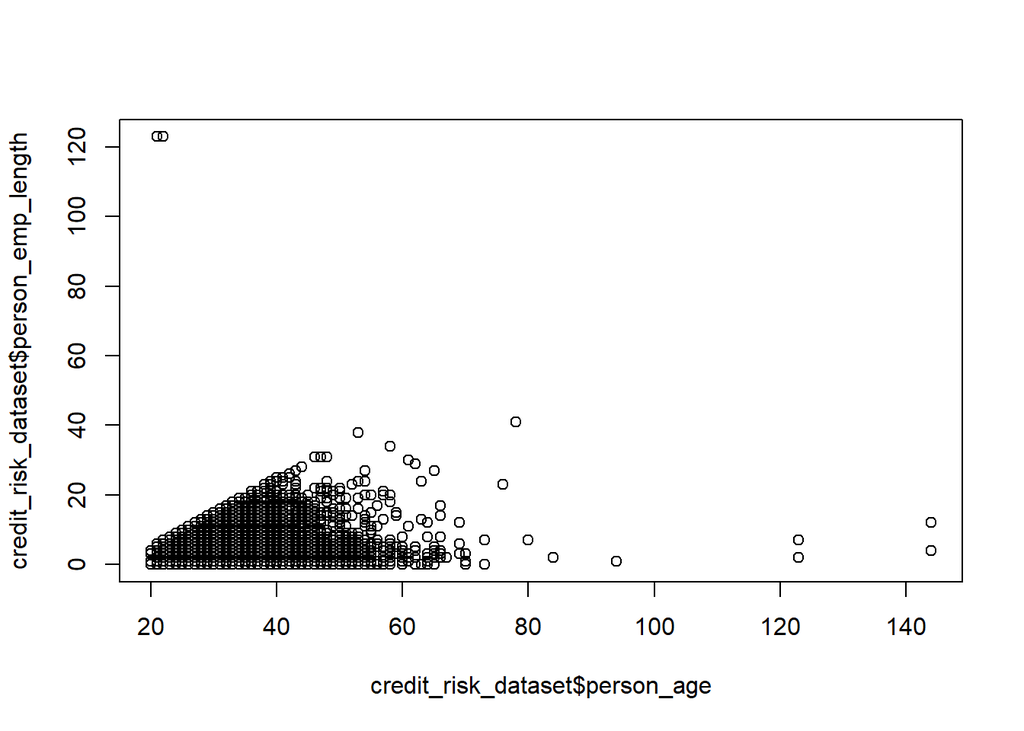

```r
plot(credit_risk_dataset$person_age, credit_risk_dataset$person_emp_length)
```

### Interpretation

```
Here we can see clearly that there are some issues on data by looking at outliers. It is impossible that two 20
years old have over 120 years of experience. Therefore we proceed by cleaning our dataset and removing illogical
outliers. We have to adjust data properly before starting the exploratory phase.
```

## Data Cleaning

```r
credit_risk <- credit_risk_dataset %>%
    filter(!is.na(person_emp_length)) %>%
    filter(!is.na(loan_int_rate)) %>%
    filter(person_age < 90) %>%
    filter(person_emp_length < 100)

summary(credit_risk)
```

```
##    person_age    person_income     person_home_ownership person_emp_length
##  Min.   :20.00   Min.   :   4000   MORTGAGE:11798        Min.   : 0.00
##  1st Qu.:23.00   1st Qu.:  39456   OTHER   :   94        1st Qu.: 2.00
##  Median :26.00   Median :  55900   OWN     : 2192        Median : 4.00
##  Mean   :27.71   Mean   :  66427   RENT    :14548        Mean   : 4.78
##  3rd Qu.:30.00   3rd Qu.:  80000                         3rd Qu.: 7.00
##  Max.   :84.00   Max.   :2039784                         Max.   :41.00
##
##             loan_intent   loan_grade   loan_amnt     loan_int_rate
##  DEBTCONSOLIDATION:4565   A:9401     Min.   :  500   Min.   : 5.42
##  EDUCATION        :5702   B:9149     1st Qu.: 5000   1st Qu.: 7.90
##  HOMEIMPROVEMENT  :3198   C:5697     Median : 8000   Median :10.99
##  MEDICAL          :5293   D:3247     Mean   : 9655   Mean   :11.04
##  PERSONAL         :4875   E: 870     3rd Qu.:12500   3rd Qu.:13.48
##  VENTURE          :4999   F: 209     Max.   :35000   Max.   :23.22
##                           G:  59
##  loan_status loan_percent_income cb_person_default_on_file
##  0:22430     Min.   :0.0000      N:23530
##  1: 6202     1st Qu.:0.0900      Y: 5102
##              Median :0.1500
##              Mean   :0.1695
##              3rd Qu.:0.2300
##              Max.   :0.8300
##
##  cb_person_cred_hist_length
##  Min.   : 2.000
##  1st Qu.: 3.000
##  Median : 4.000
##  Mean   : 5.794
##  3rd Qu.: 8.000
##  Max.   :30.000
##
```

```
Now the dataset seems better.

With the summary command we extrapolate some information about tha characteristics and the distribution of the
variables that compose our data. For instance, looking at the nature of variables we can divide them in two classes:
numerical and categorical.

We could also divide the variables conceptually. For instance, person_age, person_income, person_home_ownership and
person_emp_length rely on personal characteristics of people, while loan_intent, loan_grade, loan_amnt, loan_int_rate
, loan_status and loan_percent_income rely on their credit activity. The last two variables are of interest only for
secondary purposes.

With this in mind, we can proceed with the exploration of statistical relationships by looking at the most influential
variables.
```

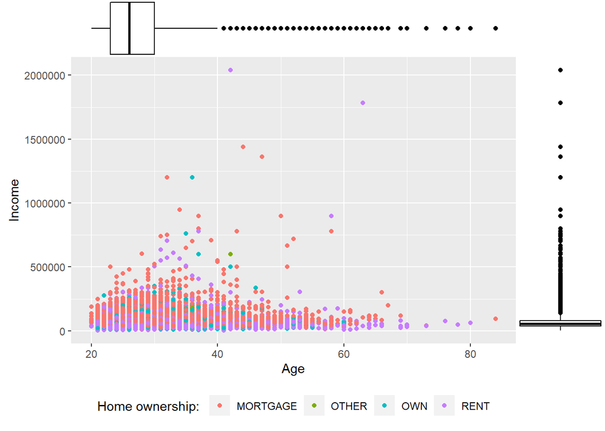

```r
plot1 <- ggplot(credit_risk, aes(person_age, person_income, col=person_home_ownership)) +
  geom_point() + ylab("Income") + xlab("Age") + labs(color = "Home ownership: ") +
  theme(legend.position="bottom")
ggExtra::ggMarginal(plot1, type = "boxplot")
```

### Interpretation of Scatter Plot 1

[output not shown]

### Familiarize with the dataset

```
First of all, we start observing statistical relationships between numerical variables. We can do this using traditional
scatterplots and boxplots. To understand the personal characteristics of people and then their credit activity, it seems
reasonable to compare the person age and income, the loan amount and the interest rate, the person income with the loan
amount and finally, the person age and the interest rate. We could also add an additional dimension (with colours) to have
a clearer overview.
```

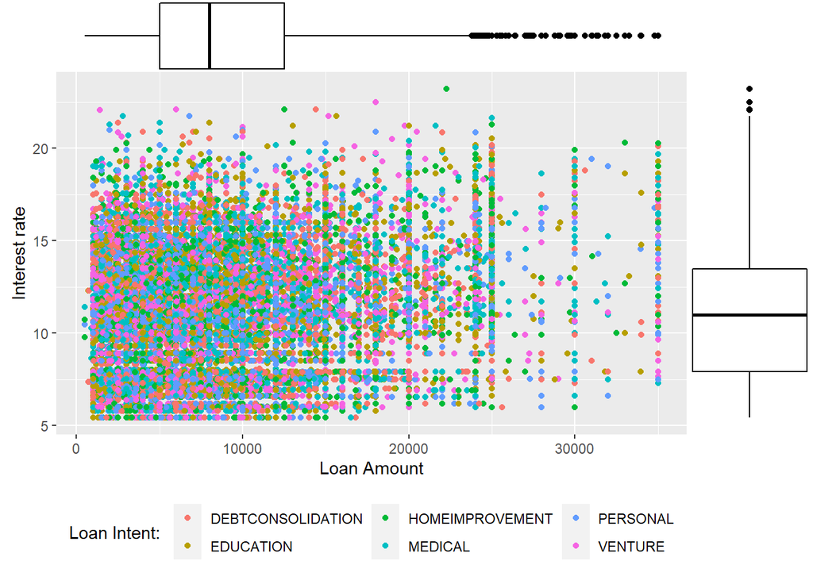

```r
plot2 <- ggplot(credit_risk, aes(loan_amnt, loan_int_rate, col=loan_intent)) +
  geom_point() + ylab("Interest rate") + xlab("Loan Amount") + labs(color = "Loan Intent: ") +
  theme(legend.position="bottom")
ggExtra::ggMarginal(plot2, type = "boxplot")
```

### Interpretation

```
This second graph represents the relationship between the loan amount taken by people and the interest rate applied.
Here, we can see that there is not a clear correlation between the two variables, thus we can say that they do not
depend from each other. Moreover, it seems that the loan intent is distributed equally in the sample, which means that
the intent does not influence at all interest rates or the loan amount. In this case distributions are normal Gaussian
with a slight skewness.
```

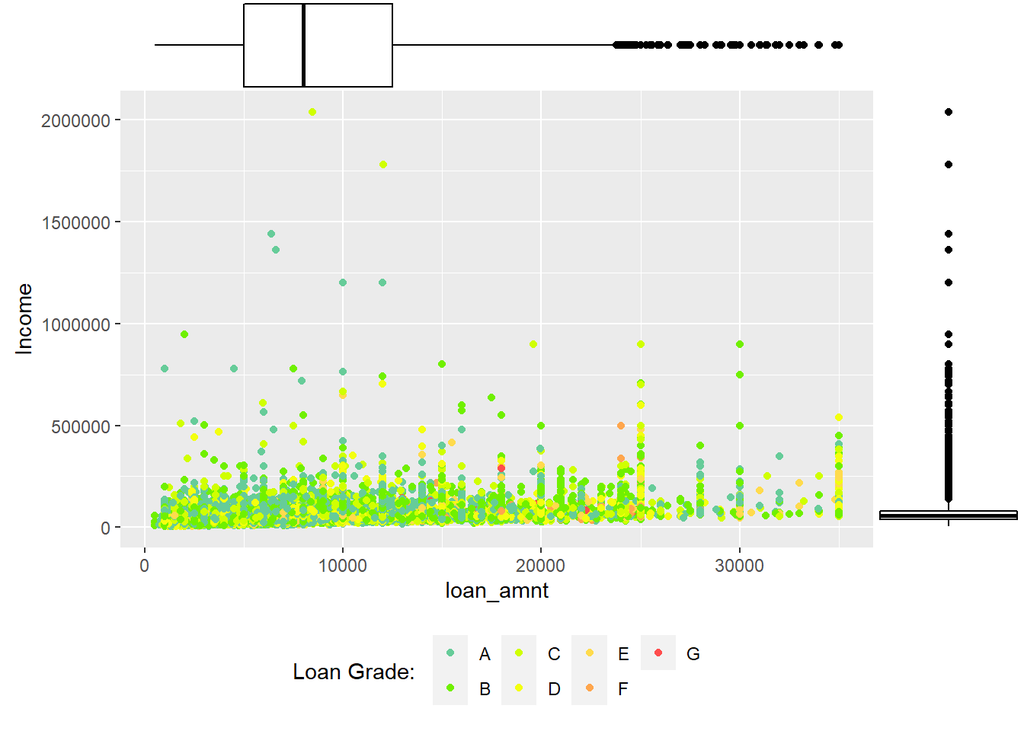

```r
plot3 <- ggplot(credit_risk, aes(loan_amnt, person_income, col=loan_grade)) +
  geom_point() + ylab("Income") + labs(color = "Loan Grade: ") + theme(legend.position="bottom") +
  scale_color_manual(values=c("#66cc99", "#70F000", "#D0FF00", "#F3FF0F", "#FFDB4D", "#FFA64D", "#FF4D4D"))
ggExtra::ggMarginal(plot3, type = "boxplot")
```

### Interpretation

```
Also in this case there is not a clear relationship between income and the loan amount. By adding different colors for
the loan grades we notice a small tendence for people with low income and with a high loan, to have a lower grade.
However, the statistical relationship is not strong.
```

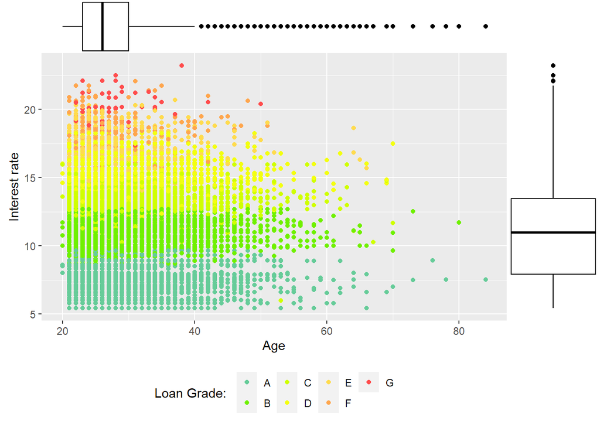

```r
plot4 <- ggplot(credit_risk, aes(person_age, loan_int_rate, col=loan_grade)) +
  geom_point() + ylab("Interest rate") + xlab("Age") +  labs(color = "Loan Grade: ") +
theme(legend.position="bottom") + scale_color_manual(values=c("#66cc99", "#70F000", "#D0FF00", "#F3FF0F", "#FFDB4D", "#FFA64D", "#FF4D4D"))
ggExtra::ggMarginal(plot4, type = "boxplot")
```

### Interpretation

[output not shown]

### Variable of interest

```
Our variable of interest is the likekihood of default given certain characteristics, therefore we look at the loan_status variable.
```

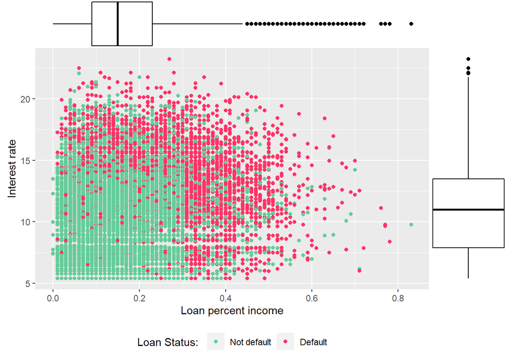

```r
plot5 <- ggplot(credit_risk, aes(loan_percent_income, loan_int_rate, col= factor(loan_status, labels = c("Not default", "Default")))) +
  geom_point() + ylab("Interest rate") + xlab("Loan percent income") + labs(color = "Loan Status: ") +
  theme(legend.position="bottom") + scale_color_manual(values=c("#66cc99", "#ff3366"))
ggExtra::ggMarginal(plot5, type = "boxplot")
```

### Interpretation

```Here we consider again the level of interest rates, in relation to the ratio between the loan amount and income. The shape of the dots suggests that there isn’t a clear relationship between these two varibles, which means that interest rates does not depend at all on the loan percent income. However, the more we approach to an higher ratio, the lower the interest rates become.

Then, if we take into account people that have defaulted in red and people that have not defaulted in green, we can clearly see a rectangular shape with threshold levels towards 12% for interest rates, and 0.3 for the loan percent income variable. This area could be considered less risky for both lenders and borrowers. This seems to be reasonable as higher interest rates and an higher income/loan ratio means that people are less likely to repay their debt.```

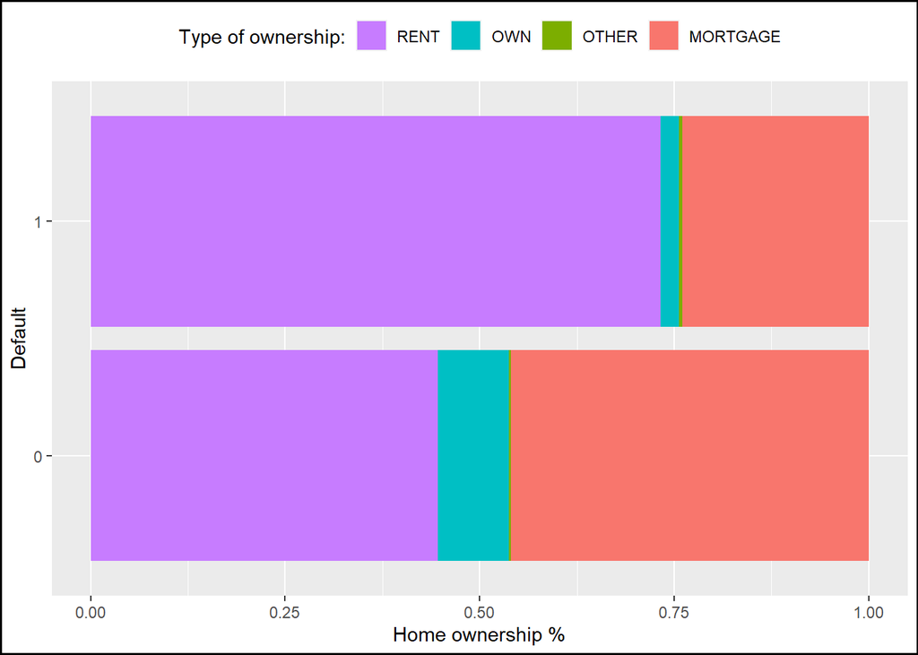

```r
ggplot(credit_risk, aes(x = factor(loan_status), fill = factor(person_home_ownership))) +
  geom_bar(position = "fill") +
  ylab("Home ownership %") + xlab("Default") + labs(fill = "Type of ownership:") +
  theme(legend.position="top", plot.background = element_rect(colour = "black", size = 1)) +
  guides(fill = guide_legend(reverse=TRUE)) +
  coord_flip()
```

### Interpretation

[output not shown]

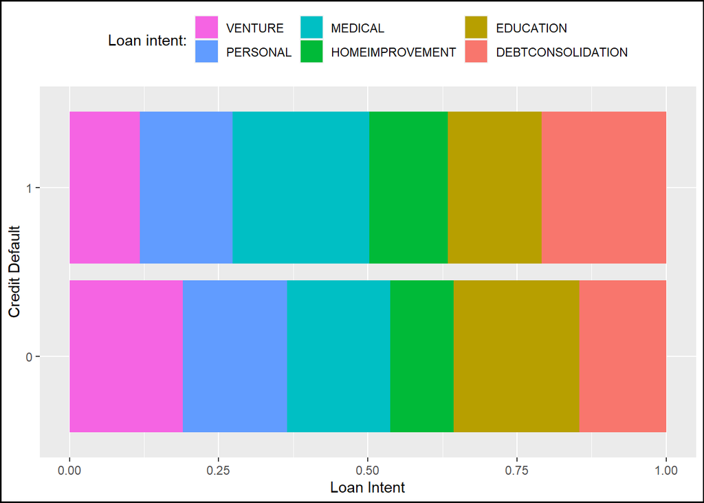

```r
ggplot(credit_risk, aes(x = factor(loan_status), fill = factor(loan_intent))) +
  geom_bar(position = "fill") +
  ylab("Loan Intent") + xlab("Credit Default") + labs(fill = "Loan intent:") +
  theme(legend.position="top", plot.background = element_rect(colour = "black", size = 1)) +
  guides(fill = guide_legend(reverse=TRUE)) +
  coord_flip()
```

### Interpretation

[output not shown]

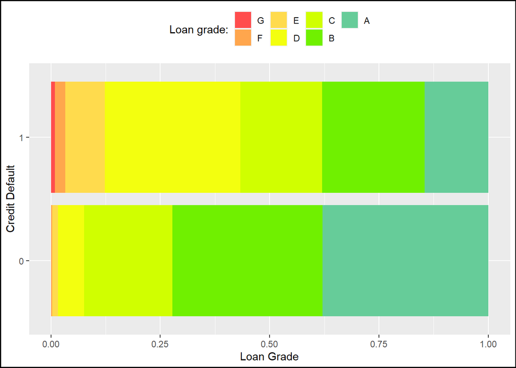

```r
ggplot(credit_risk, aes(x = factor(loan_status), fill = factor(loan_grade))) +
  geom_bar(position = "fill") + scale_fill_manual(values=c("#66cc99", "#70F000", "#D0FF00", "#F3FF0F", "#FFDB4D", "#FFA64D", "#FF4D4D")) +
  ylab("Loan Grade") + xlab("Credit Default") + labs(fill = "Loan grade:") +
  theme(legend.position="top", plot.background = element_rect(colour = "black", size = 1)) +
  guides(fill = guide_legend(reverse=TRUE)) +
  coord_flip()
```